```python
try:
    import google.colab
    IN_COLAB = True
except:
    IN_COLAB = False

if IN_COLAB:
    from google.colab import output
    output.enable_custom_widget_manager()

    import os
    import sys
    from google.colab import drive
    drive.mount('/content/drive')
    os.chdir("drive/MyDrive/ai-park")
    sys.path.insert(0, os.getcwd())
    !pip install -r requirements.txt &> /dev/null

import numpy as np
try:
    import matplotlib.pyplot as plt
except ImportError:
    print("Installing matplotlib...")
    !pip install matplotlib &> /dev/null
    import matplotlib.pyplot as plt

%matplotlib inline
```

# Qu'est-ce que la vision par ordinateur (computer vision) ?

La vision par ordinateur est le domaine qui permet à un ordinateur de :

- **Voir** : recevoir des images (caméra, photos, vidéos).
- **Comprendre** : reconnaître des objets, des personnes, des formes, du texte...
- **Décider / agir** : par exemple, freiner une voiture autonome, déverrouiller un téléphone, trier des objets sur une chaîne de production.

# Comment est-ce que l'ordinateur voit une image ?

Pour un humain, une image c’est quelque chose qu’on **observe** avec nos **yeux**.

Pour un ordinateur, une image c’est un **tableau de nombres**:

- Une image en noir et blanc : un **tableau 2D** de nombres (intensité de 0 = noir à 1 = blanc).
- Une image en couleur : souvent un **tableau 3D** (hauteur × largeur × 3 couleurs : Rouge, Vert, Bleu).

Les valeurs dans le tableau/image sont appelées des **pixels**.

```
Taille de l'image : (16, 16)
Tableau de pixels :
[[0. 0. 0. 0. 0. 0. 0. 0. 0. 0. 0. 0. 0. 0. 0. 0.]
 [0. 0. 0. 0. 0. 0. 0. 0. 0. 0. 0. 0. 0. 0. 0. 0.]
 [0. 0. 0. 0. 0. 0. 0. 0. 0. 0. 0. 0. 0. 0. 0. 0.]
 [0. 0. 0. 0. 0. 0. 0. 0. 0. 0. 0. 0. 0. 0. 0. 0.]
 [0. 0. 0. 0. 0. 0. 0. 0. 0. 0. 0. 0. 0. 0. 0. 0.]
 [0. 0. 1. 1. 1. 1. 0. 0. 0. 1. 1. 1. 1. 1. 1. 0.]
 [0. 1. 1. 0. 0. 1. 1. 0. 0. 0. 0. 1. 1. 0. 0. 0.]
 [0. 1. 1. 1. 1. 1. 1. 0. 0. 0. 0. 1. 1. 0. 0. 0.]
 [0. 1. 1. 0. 0. 1. 1. 0. 0. 0. 0. 1. 1. 0. 0. 0.]
 [0. 1. 1. 0. 0. 1. 1. 0. 0. 0. 0. 1. 1. 0. 0. 0.]
 [0. 1. 1. 0. 0. 1. 1. 0. 0. 1. 1. 1. 1. 1. 1. 0.]
 [0. 0. 0. 0. 0. 0. 0. 0. 0. 0. 0. 0. 0. 0. 0. 0.]
 [0. 0. 0. 0. 0. 0. 0. 0. 0. 0. 0. 0. 0. 0. 0. 0.]
 [0. 0. 0. 0. 0. 0. 0. 0. 0. 0. 0. 0. 0. 0. 0. 0.]
 [0. 0. 0. 0. 0. 0. 0. 0. 0. 0. 0. 0. 0. 0. 0. 0.]
 [0. 0. 0. 0. 0. 0. 0. 0. 0. 0. 0. 0. 0. 0. 0. 0.]]
```

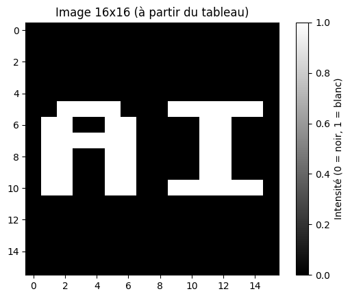

```python
# Création d'une petite image 8x8 en niveaux de gris
image = np.zeros((16, 16), dtype=float)

# Lettre "A"
image[6:11, 1:3] = 1.0
image[5, 2:6] = 1.0
image[6:11, 5:7] = 1.0
image[7, 3:5] = 1.0

# Lettre "I"
image[5, 9:15] = 1.0
image[6:10, 11:13] = 1.0
image[10, 9:15] = 1.0

print("Taille de l'image :", image.shape)
print("Tableau de pixels :")
print(image)

plt.imshow(image, cmap="gray", vmin=0, vmax=1)
plt.title("Image 16x16 (à partir du tableau)")
plt.colorbar(label="Intensité (0 = noir, 1 = blanc)")
plt.show()
```

# Comment est-ce que l'ordinateur comprend une image ?

Nous sommes capables d'interpréter une image ou des parties d'une image à l'aide de notre **cerveau**.

L'ordinateur peut "comprendre" et intéragir avec des parties de l'image à l'aide d'**opérateurs mathématiques**:

- L'opération utilisée le plus souvent sur les images c'est la **convolution**.
- Cette opération fait glisser un **filtre** sur l'image pour calculer des **combinaisons** (pondérées) de **pixels voisins**.

Un **filtre** (ou *noyau*) est souvent un petit tableau de nombres, par exemple: \begin{bmatrix} 0 & 0 & 0\\ 0 & 1 & 0\\ 0 & 0 & 0 \end{bmatrix} La **convolution** fait glisser le filtre sur une image comme une petite fenêtre:

```python
import numpy as np
import matplotlib.pyplot as plt
from matplotlib import patches, animation
from IPython.display import HTML


def convolve2d(image, kernel, stride=1, padding="same"):
    """
    Convolution 2D simple.

    image : tableau 2D
    kernel : petit tableau 2D (ex: 3x3)
    stride : pas de déplacement du noyau
    padding : "same" ou "valid", type de padding
        un padding "same" ajoute des zéros autour de l'image pour que la sortie ait la même taille que l'entrée
        un padding "valid" n'ajoute rien (taille de sortie réduite)

    Retourne le tableau 2D résultant de la convolution.
    """
    kh, kw = kernel.shape
    if padding == "same":
        pad_h = (kh - 1) // 2
        pad_w = (kw - 1) // 2
        padded_image = np.pad(image, ((pad_h, pad_h), (pad_w, pad_w)), mode='constant', constant_values=0)
    else:
        padded_image = image

    out_h = (padded_image.shape[0] - kh) // stride + 1
    out_w = (padded_image.shape[1] - kw) // stride + 1
    out = np.zeros((out_h, out_w), dtype=float)

    for i in range(out_h):
        for j in range(out_w):
            region = padded_image[i*stride:i*stride+kh, j*stride:j*stride+kw]
            out[i, j] = np.sum(region * kernel)

    return out, padded_image


# kernel = np.zeros((3, 3), dtype=float)
# kernel[1, 1] = 1.0  # filtre identité 3x3

kernel = np.ones((3, 3), dtype=float)
kernel = kernel / kernel.sum()  # filtre moyenneur 3x3

# kernel = np.asarray(
#     [
#         [1, 2, 1],
#         [2, 4, 2],
#         [1, 2, 1]
#     ],
#     dtype=float
# )
# kernel /= kernel.sum()  # filtre gaussien 3x3

copy = image.copy()
out, padded = convolve2d(copy, kernel, stride=1, padding="same")

h, w = copy.shape
ph, pw = padded.shape
kh, kw = kernel.shape
out_h, out_w = out.shape

positions = [(i, j) for i in range(out_h) for j in range(out_w)]
n_steps = len(positions)

fig, axes = plt.subplots(1, 3, figsize=(8, 4))

ax_org = axes[0]
im_org = ax_org.imshow(image, cmap="gray", vmin=0, vmax=1)
ax_org.set_title("Image originale")
ax_org.set_xticks(np.arange(-0.5, w - 1, 1))
ax_org.set_yticks(np.arange(-0.5, h - 1, 1))
ax_org.set_xticklabels(range(w), rotation=90)
ax_org.set_yticklabels(range(h))
ax_org.grid(color="lightgray", linestyle="--", linewidth=0.5, which='both', axis='both')

ax_in = axes[1]
im_in = ax_in.imshow(padded, cmap="gray", vmin=0, vmax=1)
ax_in.set_title("Image avec padding")
ax_in.set_xticks(np.arange(-0.5, pw - 1, 1))
ax_in.set_yticks(np.arange(-0.5, ph - 1, 1))
ax_in.set_xticklabels(range(pw), rotation=90)
ax_in.set_yticklabels(range(ph))
ax_in.grid(color="lightgray", linestyle="--", linewidth=0.5, which='both', axis='both')

# add a symbol on padded pixels
for i in range(pw):
    padded_pixel = patches.Rectangle(
        (i - 0.5, -0.5),  # x, y
        1, 1,
        fill=False,
        edgecolor="blue",
        linewidth=1,
        linestyle="--"
    )
    ax_in.add_patch(padded_pixel)

    padded_pixel = patches.Rectangle(
        (i - 0.5, ph - 1.5),  # x, y
        1, 1,
        fill=False,
        edgecolor="blue",
        linewidth=1,
        linestyle="--"
    )
    ax_in.add_patch(padded_pixel)

for i in range(ph):
    padded_pixel = patches.Rectangle(
        (-0.5, i - 0.5),  # x, y
        1, 1,
        fill=False,
        edgecolor="blue",
        linewidth=1,
        linestyle="--"
    )
    ax_in.add_patch(padded_pixel)

    padded_pixel = patches.Rectangle(
        (pw - 1.5, i - 0.5),  # x, y
        1, 1,
        fill=False,
        edgecolor="blue",
        linewidth=1,
        linestyle="--"
    )
    ax_in.add_patch(padded_pixel)

# kernel rectangle
rect = patches.Rectangle(
    (-0.5, -0.5),  # x, y
    kw, kh,
    fill=False,
    edgecolor="red",
    linewidth=2,
)
ax_in.add_patch(rect)

ax_out = axes[2]
out_display = np.full_like(out, np.nan, dtype=float)
im_out = ax_out.imshow(
    out_display,
    cmap="gray",
    vmin=out.min(),
    vmax=out.max()
)
ax_out.set_title("Image filtrée")
ax_out.set_xticks(np.arange(-0.5, out_w - 1, 1))
ax_out.set_yticks(np.arange(-0.5, out_h - 1, 1))
ax_out.set_xticklabels(range(out_w), rotation=90)
ax_out.set_yticklabels(range(out_h))
ax_out.grid(color="lightgray", linestyle="--", linewidth=0.5)

text_current = ax_out.text(
    0.5, -0.3, "", transform=ax_out.transAxes,
    ha="center", va="top"
)
plt.tight_layout()

def update(frame):
    i, j = positions[frame]
    rect.set_xy((j - 0.5, i - 0.5))

    disp = np.full_like(out, np.nan, dtype=float)
    for t in range(frame + 1):
        ii, jj = positions[t]
        disp[ii, jj] = out[ii, jj]
    im_out.set_data(disp)

    text_current.set_text(
        f"Position (i={i}, j={j})  valeur = {out[i, j]:.2f}"
    )

    return im_in, im_out, rect, text_current

anim = animation.FuncAnimation(
    fig,
    update,
    frames=n_steps,
    interval=75,  # ms between frames
    blit=False
)

plt.close(fig)
HTML(anim.to_jshtml())
```

[figure not shown]

# Utilité des filtres et de la convolution

Si on vous avez demandez de trouver les pixels qui ont le plus gros nombre de **voisins directs non nuls** dans l'image originale:

- Est-ce que c'est facile de le faire à partir de l'**image originale** uniquement ?
- L'**image filtrée** peut-elle nous aider ?

[figure not shown]

Les filtres permettent de **ressortir des caractéristiques de l'image** qui ne sont pas toujours évidente à trouver.

# Exemple d'application: identification des oiseaux

[figure not shown]

Pour nous aider à classifier différents types d'oiseaux, **quelles caractéristiques peut-on extraire des images précédentes ?**

- **formes**: tête, bec, ailes, ...
- **texture**: plumage (corps, ailes)
- **couleurs**: combinaisons, luminosité, saturation, ...

Il y a une vingtaine d'années, **classifier des oiseaux** était une tâche relativement **difficile** pour laquelle on créait des **filtres spéciaux à la main**.

[figure not shown]

Mais la technologie s'est améliorée, on peut laisser l'ordinateur lui même **trouver les filtres adéquats** pour notre tâche.

# Apprentissage automatique par réseau de neurones

Un **réseau de neurones** est un **algorithme d'apprentissage automatique** qui imite le fonctionnement du **cerveau**.

Cet algorithme se base sur la logique de **neurones artificiels**, qui prennent plusieurs **nombres en entrée** et calcule une **combinaison** de ces nombres **en sortie**.

[figure not shown]

Un **réseau de neurones** n'est qu'un **ensemble de neurones**, souvent **organisés en couches**.

Dans ce cas, les **sorties d'une première couche** servent comme **entrées de la couche suivante**.

[figure not shown]

Au lieu de **construire des filtres** pour extraire les **caractéristiques**, on **construit un réseau de neurones** avec des **couches**.

Plusieurs **types de couches** sont possibles, en fonction des **opérateurs linéaires** qu'on utilise.

## Couche convolutionelle (Conv1D, Conv2D, etc.)

Cette couche applique un ou plusieurs **filtres** sur l'image d'entrée. Chaque filtre calcule une **carte de caractéristiques**. On glisse le noyau sur l'image et on calcule, pour chaque position, une combinaison linéaire des pixels.

Le résultat est un **ensemble de cartes de caractéristiques** qui détectent les motifs utiles (bords, textures, etc.).

## Couche de pooling (AvgPooling, MaxPooling)

Les couches de **pooling** réduisent la **taille spatiale** (hauteur, largeur) des cartes de caractéristiques. L'idée est de **résumer localement** l'information pour réduire le nombre de paramètres.

On peut voir le pooling comme une forme d'**échantillonnage** de caractéristiques.

## Couche d'aplatissage (Flatten)

La couche d'**aplatissage** (**Flatten**) se contente de **transformer une liste multi-dimensionnelle** (hauteur, largeur, profondeur) en une **liste uni-dimensionelle** (hauteur * largeur * profondeur).

Cette couche est souvent utilisée lorsque l'on veut **passer des couches convolutionnelles** à des couches **linéaires**.

## Couche linéaire (Dense)

Une couche **linéaire** (**Dense**) applique une matrice de poids sur l'entrée. Dans un réseau de neurones **convolutionel**, les couches linéaires sont souvent les dernières couches du réseaux.

## Couche de dropout (Dropout)

La couche **Dropout** est une technique de **régularisation**. Pendant l'entraînement, elle met aléatoirement à zéro un certain **pourcentage de neurones** (par exemple 20% ou 50%) pour forcer le réseau à utiliser les connexions entres d'autres neurones. Cela évite que le réseau dépende fortement sur un **petit ensemble de neurones**.

**Après l'entrainement**, la couche de Dropout est **désactivée** pour permettre au réseau d'utiliser tous ses neurones.

# Entrainons un réseau pour reconnaître des chiffres

Dans cette section, nous allons **construire un réseau de neurones convolutif (CNN)** et l'**entraîner sur le jeu de données MNIST**.

MNIST contient des **images en niveaux de gris de chiffres manuscrits (de 0 à 9)** de taille **28×28 pixels**.

Le but est de prédire le **chiffre** correspondant à chaque image.

# Importer les bibliothèques et charger MNIST

```python
import os

import keras
import numpy as np

# Mute tensorflow/keras warnings
os.environ["TF_CPP_MIN_LOG_LEVEL"] = "3"


# Chargement des données MNIST
(x_train, y_train), (x_test, y_test) = keras.datasets.mnist.load_data()

# Normalisation en [0, 1]
x_train = x_train.astype("float32") / 255.0
x_test  = x_test.astype("float32") / 255.0

# Ajout de la dimension de canal (N, 28, 28, 1)
x_train = np.expand_dims(x_train, -1)
x_test  = np.expand_dims(x_test, -1)

print("Format de l'ensemble d'entraînement  :", x_train.shape)
print("Format de l'ensemble de test         :", x_test.shape)
```

# Visualiser quelques images de MNIST

```python
import matplotlib.pyplot as plt

# Sélection de quelques indices au hasard
num_samples = 4
indices = np.random.choice(len(x_train), size=num_samples, replace=False)
fig, axes = plt.subplots(1, num_samples, figsize=(12, 3))

for i, idx in enumerate(indices):
    image = x_train[idx]
    true_label = y_train[idx]
    axes[i].imshow(image.squeeze(), cmap="gray")
    axes[i].set_title(f"Vraie classe : {true_label}")
    axes[i].axis("off")

plt.tight_layout()
plt.show()
```

# Construire notre CNN

```python
input_shape = x_train.shape[1:]
num_classes = len(np.unique(y_train))

print("Format des images d'entrée :", input_shape)
print("Nombre de classes          :", num_classes)

model = keras.Sequential([
    keras.layers.Input(shape=input_shape),  # couche d'entrée

    # On veut ajouter quelques couches intermédiaires ici pour améliorer le réseau (Conv2D, MaxPooling2D, etc.)

    # Rappel: Il faut aplatir les images 2D en vecteurs 1D avant les couches Dense
    keras.layers.Flatten(),

    keras.layers.Dense(num_classes, activation="softmax")  # couche de sortie
])

model.build([None] + list(input_shape))
model.summary()  # Résumé des couches du modèle
```

# Compiler et entrainer le modèle

```python
model.compile(
    loss="sparse_categorical_crossentropy",
    optimizer="adam",
    metrics=["accuracy"],
)

history = model.fit(
    x_train,
    y_train,
    batch_size=128,
    epochs=3,  # augmentez ce nombre si vous voulez entrainer plus longtemps
    validation_split=0.1,
)
```

# Évaluer le réseau sur l'ensemble de test

On mesure maintenant la **perte** et la **précision** sur les données de test.

**Plus la perte s'approche de 0**, mieux est l'entrainement du modèle. **Plus la précision est haute**, moins est la chance que le réseau fasse des erreurs.

```python
test_loss, test_acc = model.evaluate(x_test, y_test, verbose=0)
print(f"Perte sur le test       : {test_loss:.4f}")
print(f"Précision sur le test   : {test_acc*100:.2f}%")
```

[output not shown]

# Visualiser quelques prédictions

Pour mieux comprendre ce que fait le modèle, on peut **afficher quelques images de test** et regarder ce que le CNN prédit.

```python
# Sélection de quelques indices au hasard
num_samples = 4
indices = np.random.choice(len(x_test), size=num_samples, replace=False)

fig, axes = plt.subplots(1, num_samples, figsize=(12, 3))

for i, idx in enumerate(indices):
    image = x_test[idx]
    true_label = y_test[idx]

    logits = model.predict(image[None, ...], verbose=0)
    pred_label = np.argmax(logits, axis=1)[0]

    axes[i].imshow(image.squeeze(), cmap="gray")
    axes[i].set_title(f"Vrai label : {true_label} / Prédiction : {pred_label}")
    axes[i].axis("off")

plt.tight_layout()
plt.show()
```

[output not shown]

# Visualiser les cartes de caractéristiques

Les **filtres** que le **réseau a appris** s'appliquent sur les images pour **extraire des caractéristiques** qui permettent de reconnaître les chiffres.

**Voyons à quoi ressemble ces caractéristiques.**

```python
def visualize_feature_maps(layer, input_image):
    intermediate_model = keras.Model(inputs=model.layers[0].input, outputs=layer.output)
    feature_maps = intermediate_model.predict(input_image[None, ...])

    num_maps = feature_maps.shape[-1]
    x_fig, y_fig = 1, num_maps
    if num_maps > 4:
        x_fig, y_fig = 4, num_maps // 4
    fig, axes = plt.subplots(x_fig, y_fig, figsize=(y_fig * 2, x_fig * 2))
    axes = axes.flatten()

    for i in range(num_maps):
        fm = feature_maps[0, :, :, i]
        axes[i].imshow(fm, cmap="gray")
        axes[i].set_title(f"Map {i+1}")
        axes[i].axis("off")

    return fig, axes

test_image = x_test[np.random.randint(len(x_test))]  # Sélection d'une image de test au hasard
n = 1  # 1ère couche Conv2D, changer n pour sélectionner une autre couche Conv2D

count = 0
conv_layer = None
for layer in model.layers:
    if isinstance(layer, keras.layers.Conv2D):
        if count == n:
            conv_layer = layer
            break
        count += 1

if conv_layer is not None:
    print(f"Visualisation des cartes de caractéristiques de la couche Conv2D numéro {n+1}")
    fig, axes = visualize_feature_maps(conv_layer, test_image)
else:
    print(f"Aucune couche Conv2D numéro {n+1} trouvée dans le modèle.")

plt.show()
```